# Bellabeat Analysis

Oscar

2023-04-10

### Business Task

Analyze Fitbit user trends to find opportunities for Bellabeat’s growth by influencing Bellabeat’s marketing strategies.

### Data Preparaion

In this phase, data is downloaded, imported, and prepped to be analyzed.

#### Loading Packages

```r
install.packages("tidyverse", repos = "http://cran.us.r-project.org")
library(tidyverse)
```

### Data Processing / Exploration

We will be processing the daily data for the users’ activity, calories burned, and sleep. The intensities will be processed by the hour so we can see when users are most active.

```r
activity <- read.csv("Fitabase Data 4.12.16-5.12.16/dailyActivity_merged.csv")
calories <- read.csv("Fitabase Data 4.12.16-5.12.16/dailyCalories_merged.csv")
intensities <- read.csv("Fitabase Data 4.12.16-5.12.16/hourlyIntensities_merged.csv")
sleep <- read.csv("Fitabase Data 4.12.16-5.12.16/sleepDay_merged.csv")


head(activity)
```

```
##           Id ActivityDate TotalSteps TotalDistance TrackerDistance
## 1 1503960366    4/12/2016      13162          8.50            8.50
## 2 1503960366    4/13/2016      10735          6.97            6.97
## 3 1503960366    4/14/2016      10460          6.74            6.74
## 4 1503960366    4/15/2016       9762          6.28            6.28
## 5 1503960366    4/16/2016      12669          8.16            8.16
## 6 1503960366    4/17/2016       9705          6.48            6.48
##   LoggedActivitiesDistance VeryActiveDistance ModeratelyActiveDistance
## 1                        0               1.88                     0.55
## 2                        0               1.57                     0.69
## 3                        0               2.44                     0.40
## 4                        0               2.14                     1.26
## 5                        0               2.71                     0.41
## 6                        0               3.19                     0.78
##   LightActiveDistance SedentaryActiveDistance VeryActiveMinutes
## 1                6.06                       0                25
## 2                4.71                       0                21
## 3                3.91                       0                30
## 4                2.83                       0                29
## 5                5.04                       0                36
## 6                2.51                       0                38
##   FairlyActiveMinutes LightlyActiveMinutes SedentaryMinutes Calories
## 1                  13                  328              728     1985
## 2                  19                  217              776     1797
## 3                  11                  181             1218     1776
## 4                  34                  209              726     1745
## 5                  10                  221              773     1863
## 6                  20                  164              539     1728
```

```r
head(calories)
```

```
##           Id ActivityDay Calories
## 1 1503960366   4/12/2016     1985
## 2 1503960366   4/13/2016     1797
## 3 1503960366   4/14/2016     1776
## 4 1503960366   4/15/2016     1745
## 5 1503960366   4/16/2016     1863
## 6 1503960366   4/17/2016     1728
```

```r
head(intensities)
```

```
##           Id          ActivityHour TotalIntensity AverageIntensity
## 1 1503960366 4/12/2016 12:00:00 AM             20         0.333333
## 2 1503960366  4/12/2016 1:00:00 AM              8         0.133333
## 3 1503960366  4/12/2016 2:00:00 AM              7         0.116667
## 4 1503960366  4/12/2016 3:00:00 AM              0         0.000000
## 5 1503960366  4/12/2016 4:00:00 AM              0         0.000000
## 6 1503960366  4/12/2016 5:00:00 AM              0         0.000000
```

```r
head(sleep)
```

```
##           Id              SleepDay TotalSleepRecords TotalMinutesAsleep
## 1 1503960366 4/12/2016 12:00:00 AM                 1                327
## 2 1503960366 4/13/2016 12:00:00 AM                 2                384
## 3 1503960366 4/15/2016 12:00:00 AM                 1                412
## 4 1503960366 4/16/2016 12:00:00 AM                 2                340
## 5 1503960366 4/17/2016 12:00:00 AM                 1                700
## 6 1503960366 4/19/2016 12:00:00 AM                 1                304
##   TotalTimeInBed
## 1            346
## 2            407
## 3            442
## 4            367
## 5            712
## 6            320
```

```r
str(activity)
```

```
## 'data.frame':    940 obs. of  15 variables:
##  $ Id                      : num  1.5e+09 1.5e+09 1.5e+09 1.5e+09 1.5e+09 ...
##  $ ActivityDate            : chr  "4/12/2016" "4/13/2016" "4/14/2016" "4/15/2016" ...
##  $ TotalSteps              : int  13162 10735 10460 9762 12669 9705 13019 15506 10544 9819 ...
##  $ TotalDistance           : num  8.5 6.97 6.74 6.28 8.16 ...
##  $ TrackerDistance         : num  8.5 6.97 6.74 6.28 8.16 ...
##  $ LoggedActivitiesDistance: num  0 0 0 0 0 0 0 0 0 0 ...
##  $ VeryActiveDistance      : num  1.88 1.57 2.44 2.14 2.71 ...
##  $ ModeratelyActiveDistance: num  0.55 0.69 0.4 1.26 0.41 ...
##  $ LightActiveDistance     : num  6.06 4.71 3.91 2.83 5.04 ...
##  $ SedentaryActiveDistance : num  0 0 0 0 0 0 0 0 0 0 ...
##  $ VeryActiveMinutes       : int  25 21 30 29 36 38 42 50 28 19 ...
##  $ FairlyActiveMinutes     : int  13 19 11 34 10 20 16 31 12 8 ...
##  $ LightlyActiveMinutes    : int  328 217 181 209 221 164 233 264 205 211 ...
##  $ SedentaryMinutes        : int  728 776 1218 726 773 539 1149 775 818 838 ...
##  $ Calories                : int  1985 1797 1776 1745 1863 1728 1921 2035 1786 1775 ...
```

```r
str(calories)
```

```
## 'data.frame':    940 obs. of  3 variables:
##  $ Id         : num  1.5e+09 1.5e+09 1.5e+09 1.5e+09 1.5e+09 ...
##  $ ActivityDay: chr  "4/12/2016" "4/13/2016" "4/14/2016" "4/15/2016" ...
##  $ Calories   : int  1985 1797 1776 1745 1863 1728 1921 2035 1786 1775 ...
```

```r
str(intensities)
```

```
## 'data.frame':    22099 obs. of  4 variables:
##  $ Id              : num  1.5e+09 1.5e+09 1.5e+09 1.5e+09 1.5e+09 ...
##  $ ActivityHour    : chr  "4/12/2016 12:00:00 AM" "4/12/2016 1:00:00 AM" "4/12/2016 2:00:00 AM" "4/12/2016 3:00:00 AM" ...
##  $ TotalIntensity  : int  20 8 7 0 0 0 0 0 13 30 ...
##  $ AverageIntensity: num  0.333 0.133 0.117 0 0 ...
```

```r
str(sleep)
```

```
## 'data.frame':    413 obs. of  5 variables:
##  $ Id                : num  1.5e+09 1.5e+09 1.5e+09 1.5e+09 1.5e+09 ...
##  $ SleepDay          : chr  "4/12/2016 12:00:00 AM" "4/13/2016 12:00:00 AM" "4/15/2016 12:00:00 AM" "4/16/2016 12:00:00 AM" ...
##  $ TotalSleepRecords : int  1 2 1 2 1 1 1 1 1 1 ...
##  $ TotalMinutesAsleep: int  327 384 412 340 700 304 360 325 361 430 ...
##  $ TotalTimeInBed    : int  346 407 442 367 712 320 377 364 384 449 ...
```

#### Data Manipulation: Cleaning and aggregating to find the average hourly intensity of users

Since the original format was in a string format, I had to convert the string to datetime in order to extract the HMS by reconverting to HMS in string format in order to aggregate and find the average intensity for all users.

```r
intensities$ActivityHour <- mdy_hms(intensities$ActivityHour)
intensities$ActivityHour = format(intensities$ActivityHour, "%H:%M:%S")


class(intensities$ActivityHour)
```

```
## [1] "character"
```

## Data Analysis

```r
n_distinct(activity$Id)
```

```
## [1] 33
```

```r
n_distinct(calories$Id)
```

```
## [1] 33
```

```r
n_distinct(intensities$Id)
```

```
## [1] 33
```

```r
n_distinct(sleep$Id)
```

```
## [1] 24
```

With the ‘n_distinct’ function, we are able to identify that there are 33 participants in daily activities, calories, and intensities, while sleep has 24. Since the discrepancies between 33 and 24 is not too large, we will continue using these data sets for our analysis.

```r
activity %>%
  select(VeryActiveMinutes, FairlyActiveMinutes, LightlyActiveMinutes, SedentaryMinutes, Calories) %>%
  summary()
```

```
##  VeryActiveMinutes FairlyActiveMinutes LightlyActiveMinutes SedentaryMinutes
##  Min.   :  0.00    Min.   :  0.00      Min.   :  0.0        Min.   :   0.0
##  1st Qu.:  0.00    1st Qu.:  0.00      1st Qu.:127.0        1st Qu.: 729.8
##  Median :  4.00    Median :  6.00      Median :199.0        Median :1057.5
##  Mean   : 21.16    Mean   : 13.56      Mean   :192.8        Mean   : 991.2
##  3rd Qu.: 32.00    3rd Qu.: 19.00      3rd Qu.:264.0        3rd Qu.:1229.5
##  Max.   :210.00    Max.   :143.00      Max.   :518.0        Max.   :1440.0
##     Calories
##  Min.   :   0
##  1st Qu.:1828
##  Median :2134
##  Mean   :2304
##  3rd Qu.:2793
##  Max.   :4900
```

Looking at the daily activity’s averages(mean) in this summary, we can see that the Sedentary Minutes(991 minutes or 16.5 hours) is more than 4x the combined minutes from Very Active, Fairly Active, and Lightly Active(combined sum: 228 minutes or 4 hours). This massive difference may give us a clue that most Fitbit users are inactive. Looking into the Sleep Minutes may give us a better clue as to how much of those Sedentary Minutes are spent asleep.

```r
sleep %>%
  select(TotalMinutesAsleep, TotalTimeInBed) %>%
  summary()
```

```
##  TotalMinutesAsleep TotalTimeInBed
##  Min.   : 58.0      Min.   : 61.0
##  1st Qu.:361.0      1st Qu.:403.0
##  Median :433.0      Median :463.0
##  Mean   :419.5      Mean   :458.6
##  3rd Qu.:490.0      3rd Qu.:526.0
##  Max.   :796.0      Max.   :961.0
```

It looks like users spend a little under half their inactivity in bed. Which still leaves 532 minutes or about 9 hours inactive outside of bed. With this 9 hour inactivity remainder, we can conclude that users may be busily inactive during their full time job, or their routine is full of inactivity.

```r
avgIntensities <- intensities %>%
  group_by(ActivityHour) %>%
  summarize(TotalAvgIntensity = mean(TotalIntensity))

intensities %>%
  group_by(ActivityHour) %>%
  summarize(TotalAvgIntensity = mean(TotalIntensity))
```

```
## # A tibble: 24 × 2
##    ActivityHour TotalAvgIntensity
##    <chr>                    <dbl>
##  1 00:00:00                 2.13
##  2 01:00:00                 1.42
##  3 02:00:00                 1.04
##  4 03:00:00                 0.444
##  5 04:00:00                 0.633
##  6 05:00:00                 4.95
##  7 06:00:00                 7.77
##  8 07:00:00                10.7
##  9 08:00:00                14.7
## 10 09:00:00                15.4
## # ℹ 14 more rows
```

## Data Visualization

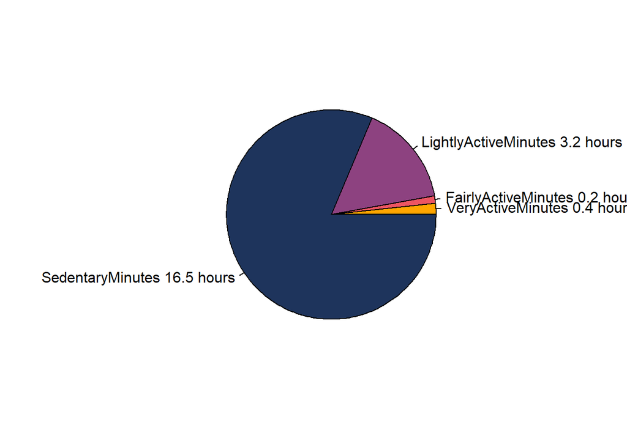

```r
selectActivity <- activity %>%
  select(VeryActiveMinutes, FairlyActiveMinutes, LightlyActiveMinutes, SedentaryMinutes)

activityPlot <- colMeans(selectActivity)

hours <- round(activityPlot / 60, digits = 1)
lbls <- paste(names(activityPlot), hours, "hours")

pie(activityPlot, col = c("#ffa600", "#ed5562", "#8d4280", "#1e345c"), labels = lbls)
```

Here we can see the massive coverage of Sedentary Minutes compared to all the other active states combined. From the plot, the Sedentary minutes take up approximately 16.5 hours or 81% of the total average activity.

To get a clearer understanding, we can see when users are mostly inactive. Here we can see the difference of intensities after 5PM from users.

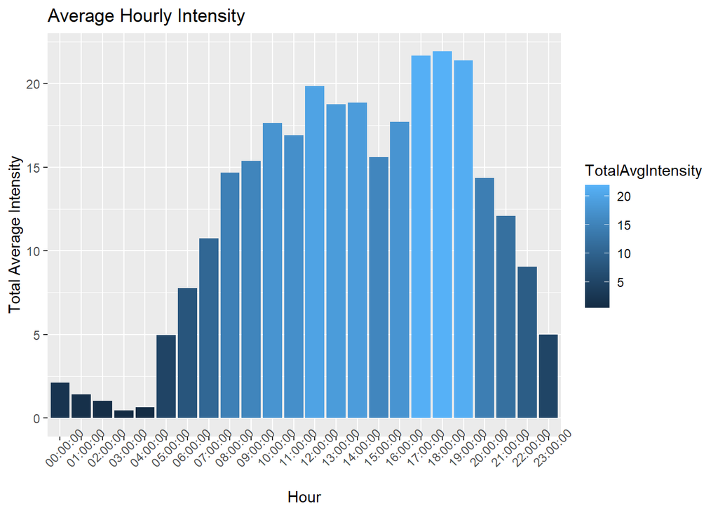

```r
ggplot(avgIntensities, aes(x=ActivityHour, y=TotalAvgIntensity)) +
  geom_bar(stat = "identity", aes(fill=TotalAvgIntensity)) +
  theme(axis.text.x = element_text(angle = 45)) +
  labs(title = "Average Hourly Intensity",
       x = "Hour",
       y = "Total Average Intensity")
```

## Conlusions & Reccommendations

Bellabeat can

- send users motivational messages based on their most active time of day to further push them to be active.
- send sleep reminders based on their time of inactivity at night
- award users who have completed workouts to motivate them to continue being active
- set a program for users to interact and challenge their friends